# Data 605 Discussion - Week 13

William Jasmine

2023-04-25

Question comes from [“APEX Calculus”](https://open.umn.edu/opentextbooks/textbooks/198) by Gregory Hartman.

# Question 11, Section 7.5

## Problem Description:

A box weighing 2 lbs lifts 10 lbs of sand vertically by 50 ft. A crack in the box allows the sand to leak out such that 9 lbs of sand is in the box at the end of the trip. Assume the sand leaked out at a uniform rate. What is the total work done in lifting the box and sand?

## Solution

The work $W$ done on the box can be found via the following formula:

$$\begin{equation}
W = \int_a^b F(x) \ dx
\end{equation}$$

where $a$ and $b$ are the beginning and end distances over which the force was applied. In this case, $F(x)$ represents the weight of the box as it makes its journey, since this is the force required to lift the box against gravity. Given that sand leaves the box at a uniform rate, we know that $F(x)$ must be a linear function, and we know from the problem that $F(0) = 10 + 2 = 12$ and $F(50) = 9 + 2 = 11$. Using the fact that the equation of a line is $y = mx + b$, this allows to determine that $F(x) = -\frac{1}{50}x + 12$. This equation is plotted below:

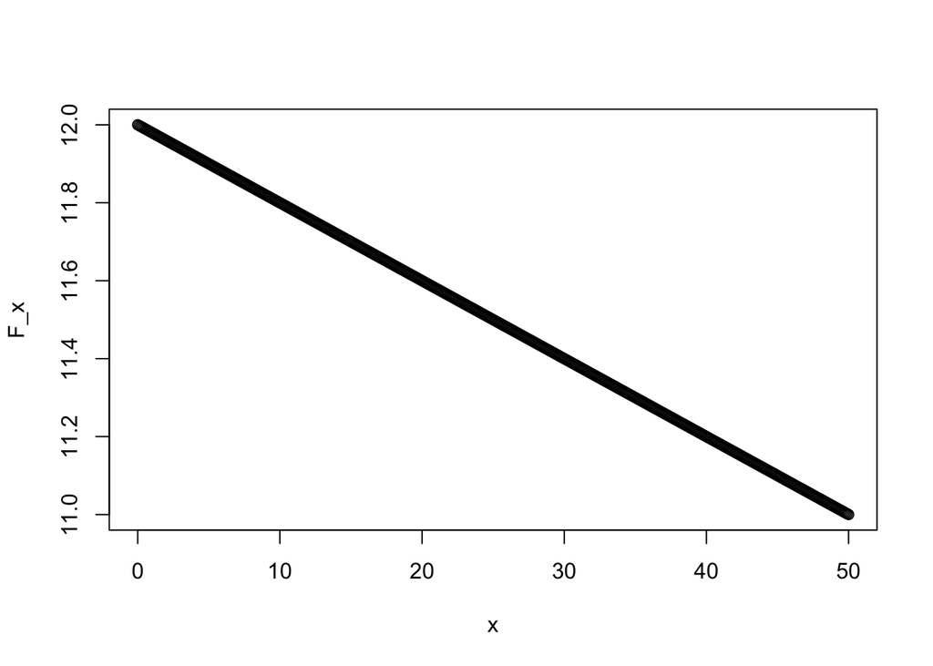

```r
x <- seq(0,50, 0.1)
F_x <- (-1/50) * x + 12
plot(x, F_x)
```

Thus, the integral needed to be solved is as follows:

$$W = \int_a^b F(x) \ dx = \int_0^{50} -\frac{1}{50}x + 12 dx$$

Solving the integral gives:

$$\begin{align}
W &= -\frac{x^2}{100} + 12 x |_0^{50} \\
W &= -\frac{50^2}{100} + 12(50) \\
W &= -\frac{2500}{100} + 600 \\
W &= 575 \ \text{lb-ft}
\end{align}$$

If you wanted to solve in R:

```r
f <- function(x){-(1/50)*x + 12}
W <- integrate(f, lower = 0, upper = 50)
print(W)
```

```
## 575 with absolute error < 6.4e-12
```